# EP06

Equipo 6

2023-11-16

### Contexto.

Un estudio recolectó medidas anatómicas de 247 hombres y 260 mujeres (Heinz et al., 2003). El estudio incluyó nueve mediciones del esqueleto (ocho diámetros y una profundidad de hueso a hueso) y doce mediciones de grosor (circunferencias) que incluyen el tejido. La siguiente tabla detalla las variables registradas en este estudio:

1. Biacromial.diameter : Diámetro biacromial (a la altura de los hombros) cm
2. Biiliac.diameter : Diámetro biiliaco (a la altura de la pelvis) cm
3. Bitrochanteric.diameter : Diámetro bitrocantéreo (a la altura de las caderas) cm
4. Chest.depth : Profundidad del pecho (entre la espina y el esternón a la altura de los pezones) cm
5. Chest.diameter : Diámetro del pecho (a la altura de los pezones) cm
6. Elbows.diameter : Suma de los diámetros de los codos cm
7. Wrists.diameter : Suma de los diámetros de las muñecas cm
8. Knees.diameter : Suma de los diámetros de las rodillas cm
9. Ankles.diameter : Suma de los diámetros de los tobillos cm
10. Shoulder.Girth : Grosor de los hombros sobre los músculos deltoides cm
11. Chest.Girth : Grosor del pecho, sobre tejido mamario en mujeres y a la altura de los pezones en varones cm
12. Waist.Girth : Grosor a la altura de la cintura cm
13. Navel.Girth : Grosor a la altura del ombligo cm
14. Hip.Girth : Grosor a la altura de las caderas cm
15. Thigh.Girth : Grosor promedio de ambos muslos bajo el pliegue del glúteo cm
16. Bicep.Girth : Grosor promedio de ambos bíceps, brazos flectados cm
17. Forearm.Girth : Grosor promedio de ambos antebrazos, brazos extendidos palmas hacia arriba cm
18. Knee.Girth : Grosor promedio de ambas rodillas, posición levemente flectada, medición arriba de la rótula cm
19. Calf.Maximum.Girth : Grosor promedio de la parte más ancha de ambas pantorrillas cm
20. Ankle.Minimum.Girth : Grosor promedio de la parte más delgada de ambos tobillos cm
21. Wrist.Minimum.Girth : Grosor promedio de la parte más delgada de ambas muñecas cm
22. Age : Edad Años
23. Weight : Peso Kg
24. Height : Estatura cm
25. Gender : Género 1: hombre ; 0: mujer

### Preguntas.

1. Definir la semilla a utilizar, que corresponde a los últimos cuatro dígitos del RUN (sin considerar el dígito verificador) del integrante de menor edad del equipo.
2. Seleccionar una muestra de 50 mujeres (si la semilla es un número par) o 50 hombres (si la semilla es impar).
3. Seleccionar de forma aleatoria ocho posibles variables predictoras.
4. Seleccionar, de las otras variables, una que el equipo considere que podría ser útil para predecir la variable Peso, justificando bien esta selección.
5. Usando el entorno R, construir un modelo de regresión lineal simple con el predictor seleccionado en el paso anterior.
6. Usando herramientas para la exploración de modelos del entorno R, buscar entre dos y cinco predictores de entre las variables seleccionadas al azar en el punto 3, para agregar al modelo de regresión lineal simple obtenido en el paso 5.
7. Evaluar los modelos y “arreglarlos” en caso de que tengan algún problema con las condiciones que deben cumplir.
8. Evaluar el poder predictivo del modelo en datos no utilizados para construirlo (o utilizando validación cruzada).

### Lectura, manipulación y selección de datos

**1. Definir la semilla a utilizar, que corresponde a los últimos cuatro dígitos del RUN (sin considerar el dígito verificador) del integrante de menor edad del equipo.**

```r
set.seed(1624) #Se Define la semilla
```

**2. Seleccionar una muestra de 50 mujeres (si la semilla es un número par) o 50 hombres (si la semilla es impar).**

```r
datos <- read.csv2("EP09 Datos.csv")
head(datos)
```

```
##   Biacromial.diameter Biiliac.diameter Bitrochanteric.diameter Chest.depth
## 1                42.9             26.0                    31.5        17.7
## 2                43.7             28.5                    33.5        16.9
## 3                40.1             28.2                    33.3        20.9
## 4                44.3             29.9                    34.0        18.4
## 5                42.5             29.9                    34.0        21.5
## 6                43.3             27.0                    31.5        19.6
##   Chest.diameter Elbows.diameter Wrists.diameter Knees.diameter Ankles.diameter
## 1           28.0            13.1            10.4           18.8            14.1
## 2           30.8            14.0            11.8           20.6            15.1
## 3           31.7            13.9            10.9           19.7            14.1
## 4           28.2            13.9            11.2           20.9            15.0
## 5           29.4            15.2            11.6           20.7            14.9
## 6           31.3            14.0            11.5           18.8            13.9
##   Shoulder.Girth Chest.Girth Waist.Girth Navel.Girth Hip.Girth Thigh.Girth
```

[output cut: 20 more lines]

```r
mujeres <- filter(datos, Gender == 0)
muestra <- mujeres[sample(nrow(mujeres), 50), ]  #Se selecciona una miestra de 50 mujeres
```

**3. Seleccionar de forma aleatoria ocho posibles variables predictoras.**

```r
predictores <- sample(24, 8) #Se seleciona de forma aleatoria ocho posibles variables predictoras.
predictores
```

```
## [1] 19 22  5  6 10 11  3 21
```

**4. Seleccionar, de las otras variables, una que el equipo considere que podría ser útil para predecir la variable Peso, justificando bien esta selección.**

Se realiza un análisis de correlación con respecto a la variable de interés, que en este caso es “Weight” (Peso).El análisis de correlación es una etapa clave en la identificación de variables potencialmente relevantes para el modelo, ya que permite evaluar la relación inicial entre las variables y la variable objetivo, facilitando la toma de decisiones en la selección de predictores para la construcción del modelo de regresión.

```r
correlacion <- cor(muestra)
max_cor <- max(correlacion[23, -23])

indice_max_cor <- which.max(correlacion[23, -23])
indice_max_cor
```

```
## Hip.Girth
##        14
```

La elección de la variable “Hip.Girth” se fundamenta en el análisis de correlación previo, donde se evaluaron las relaciones entre las variables predictoras y la variable de respuesta, que es “Weight” (Peso). La variable “Hip.Girth” emergió como la que presenta la mayor correlación positiva con el peso de los individuos.Seleccionar la variable con la correlación más alta tiene implicaciones significativas en la construcción del modelo de regresión. La alta correlación sugiere que existe una relación lineal fuerte entre el grosor de cadera y el peso. Al incorporar esta variable al modelo, se busca capturar y aprovechar esta relación para mejorar la capacidad predictiva del modelo.

Dado la selección de la variable “Hip.Girth” se construye un modelo de regresión lineal simple.

```r
muestraP <- muestra[predictores]
muestraP$Weight <- muestra$Weight
muestraP$Hip.Girth <- muestra$Hip.Girth
head(muestraP)
```

```
##     Calf.Maximum.Girth Age Chest.diameter Elbows.diameter Shoulder.Girth
## 57                32.5  21           25.4            13.4           94.5
## 157               32.7  40           26.4            12.2          105.3
## 113               34.2  25           23.3            10.7           99.2
## 246               32.7  19           25.6            11.8           92.8
## 39                38.0  19           25.9            12.9          100.1
## 110               37.0  20           29.3            12.4          110.7
##     Chest.Girth Bitrochanteric.diameter Wrist.Minimum.Girth Weight Hip.Girth
## 57         86.5                    32.4                14.6   60.7      94.0
## 157        87.6                    30.4                14.7   55.9      92.0
## 113        80.0                    29.6                14.2   51.8      91.2
## 246        87.6                    31.7                15.2   60.0      97.7
## 39         92.8                    30.8                15.3   67.9     102.6
## 110        92.2                    30.4                16.0   65.2     100.0
```

```r
#MLS
modelo <- lm(Weight ~ Hip.Girth, data = muestraP)
print(summary(modelo))
```

```
##
## Call:
## lm(formula = Weight ~ Hip.Girth, data = muestraP)
##
## Residuals:
##    Min     1Q Median     3Q    Max
## -8.722 -2.438 -0.880  2.329  8.975
##
## Coefficients:
##              Estimate Std. Error t value Pr(>|t|)
## (Intercept) -48.15629    8.25429  -5.834 4.49e-07 ***
## Hip.Girth     1.14398    0.08524  13.421  < 2e-16 ***
## ---
## Signif. codes:  0 '***' 0.001 '**' 0.01 '*' 0.05 '.' 0.1 ' ' 1
##
## Residual standard error: 4.232 on 48 degrees of freedom
## Multiple R-squared:  0.7896, Adjusted R-squared:  0.7852
## F-statistic: 180.1 on 1 and 48 DF,  p-value: < 2.2e-16
```

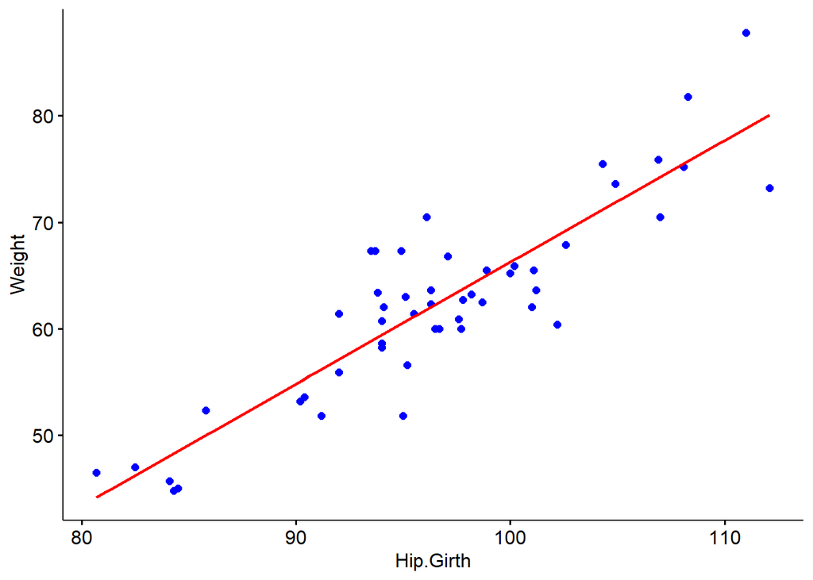

```r
#Graficar el modelo
p <- ggscatter(muestra, x = "Hip.Girth", y = "Weight", color = "blue", fill = "blue")
p <- p + geom_smooth(method = lm, se = FALSE, colour = "red")
print(p)
```

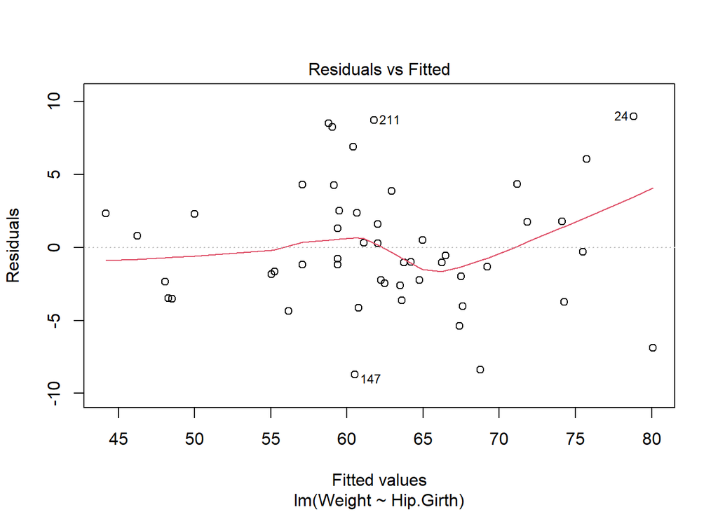

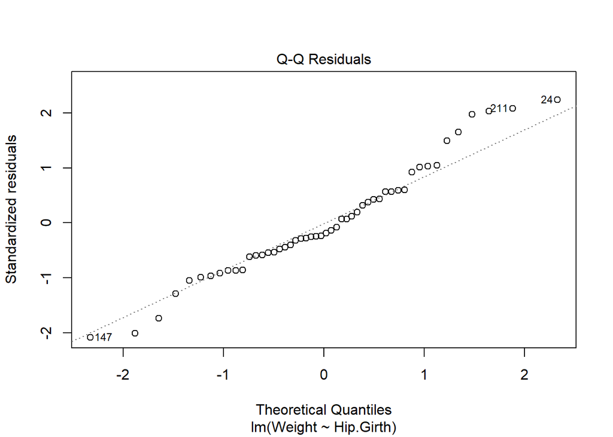

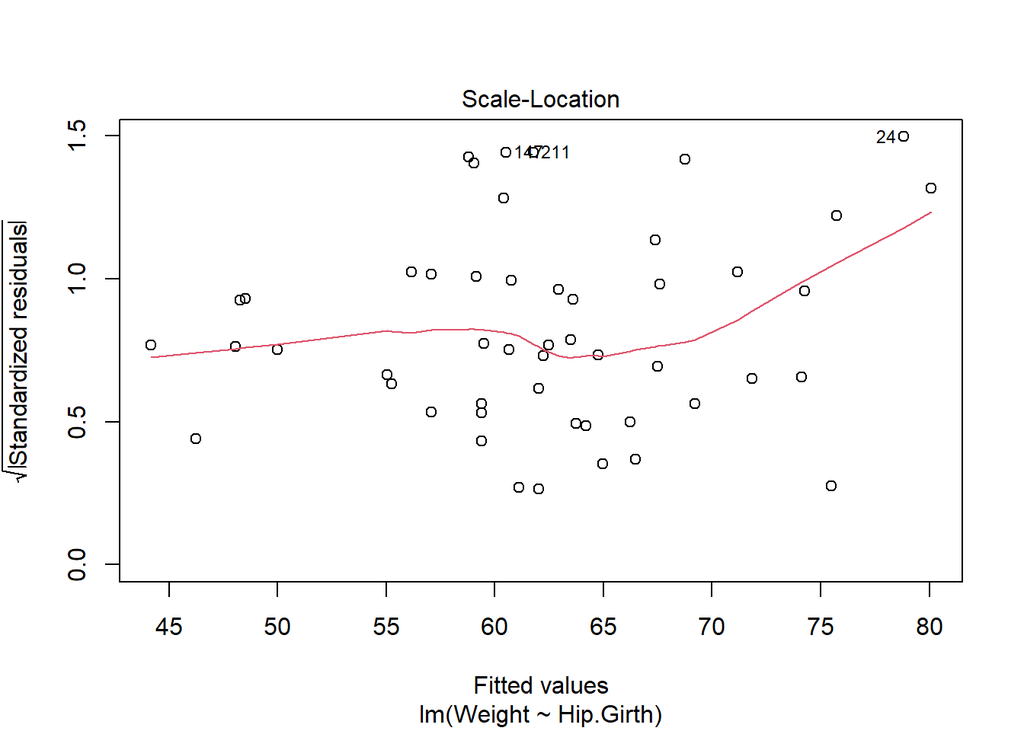

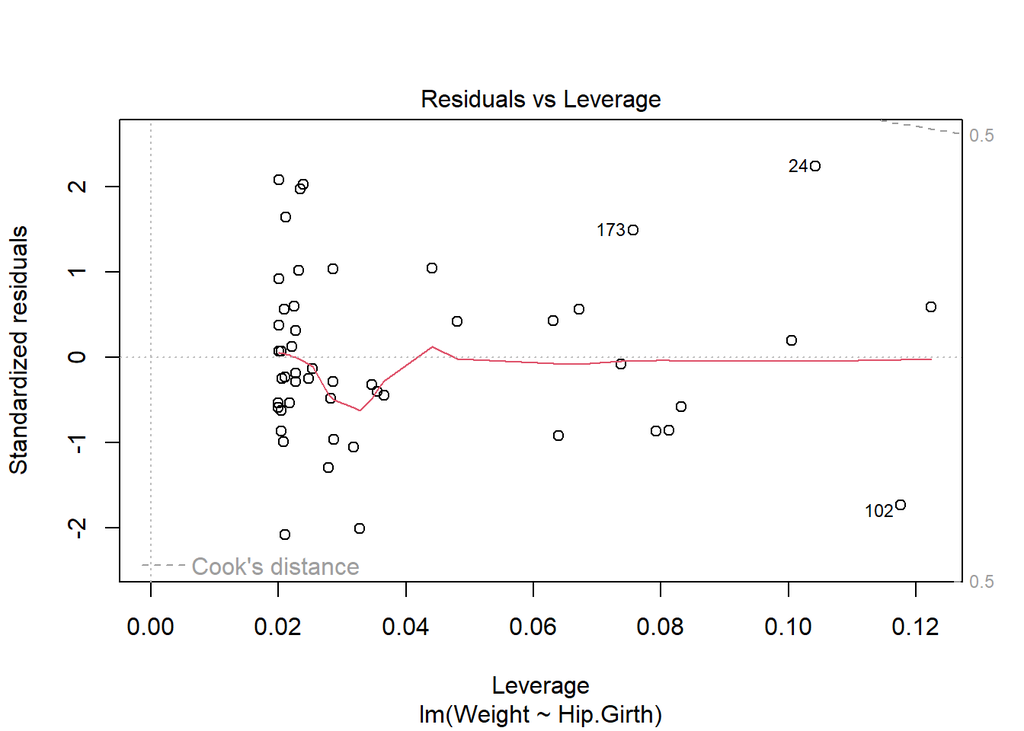

```r
# Crear gráficos para evaluar el modelo.
plot(modelo)
```

```r
#Verificar normalidad
shapiro.test(modelo$residuals)
```

```
##
##  Shapiro-Wilk normality test
##
## data:  modelo$residuals
## W = 0.96816, p-value = 0.1945
```

### Análisis de condiciones para RLS

Análisis de condiciones:

1. Los datos presentan aproximadamente una relación lineal.
2. La distribución de los residuos es cercana a la normal (p > 0.05).
3. La variabilidad de los puntos en torno a la línea de mínimos cuadrados es aproximadamente constante.
4. Las observaciones son independientes entre sí.

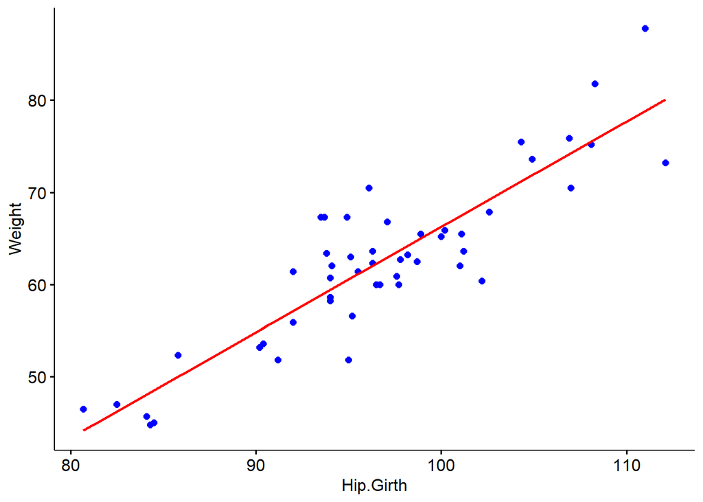

```r
# Se analiza la relación lineal
p <- ggscatter(muestraP, x = "Hip.Girth", y = "Weight", color = "blue", fill = "blue") +
  geom_smooth(method = lm, se = FALSE, colour = "red")
print(p)
```

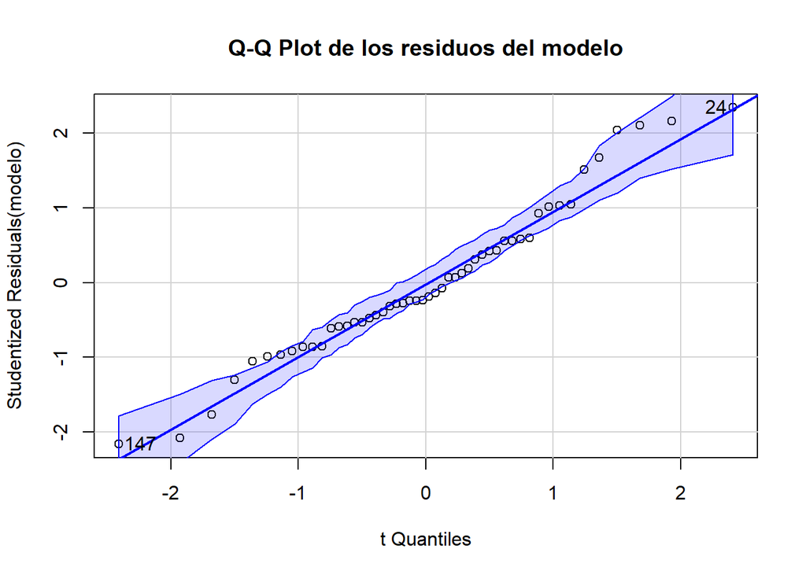

```
## 147  24
##  30  49
```

```r
# Se analiza la normalidad de los residuos
qqPlot(modelo, main="Q-Q Plot de los residuos del modelo")
```

```r
shapiro_result <- shapiro.test(modelo$residuals)
print(shapiro_result)
```

```
##
##  Shapiro-Wilk normality test
##
## data:  modelo$residuals
## W = 0.96816, p-value = 0.1945
```

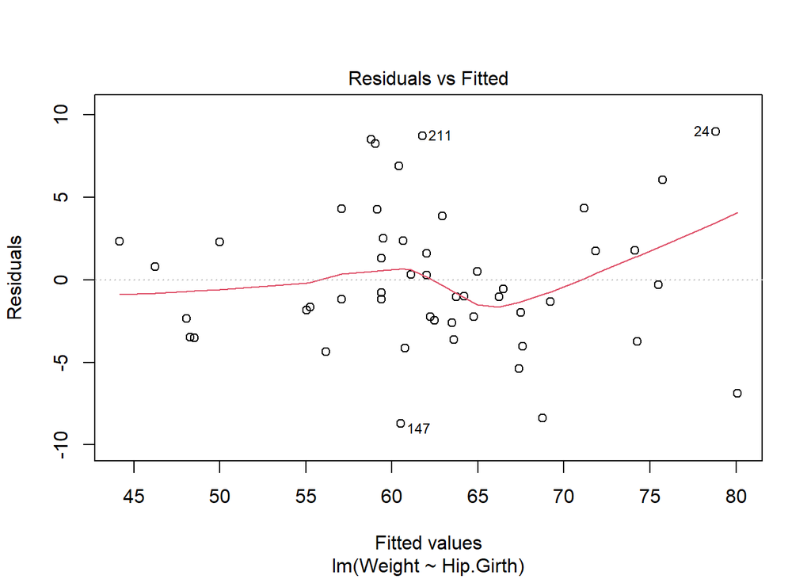

```r
plot(modelo, which = 1)
```

```r
# Se analiza la homocedasticidad
bptest_result <- bptest(modelo)
print(bptest_result)
```

```
##
##  studentized Breusch-Pagan test
##
## data:  modelo
## BP = 2.4314, df = 1, p-value = 0.1189
```

Por lo tanto las condiciones para el modelo de regresión lineal se cumplen.

1. Un gráfico en que los residuos se distribuyen aleatoriamente en torno a la línea de valor 0, sugiere que es razonable suponer que las variables presentan una relación lineal.

Pregunta a realizar:

**6. Usando herramientas para la exploración de modelos del entorno R, buscar entre dos y cinco predictores de entre las variables seleccionadas al azar en el punto 3, para agregar al modelo de regresión lineal simple obtenido en el paso 5.**

```r
set.seed(1624)

# Modelo nulo a evaluar
nulo <- lm(Weight ~ 1, data = muestraP)

#Modelo completo para evaluar adicion de datos
completo <- lm(Weight ~ ., data = muestraP)

modMejorado <- update(nulo, . ~ . + Hip.Girth)

add1(modMejorado, scope = completo)
```

```
## Single term additions
##
## Model:
## Weight ~ Hip.Girth
##                         Df Sum of Sq    RSS    AIC
## <none>                               859.53 146.22
## Calf.Maximum.Girth       1    251.65 607.89 130.90
## Age                      1      1.53 858.00 148.13
## Chest.diameter           1    129.56 729.97 140.05
## Elbows.diameter          1    271.51 588.02 129.24
## Shoulder.Girth           1    165.87 693.66 137.50
## Chest.Girth              1    298.79 560.74 126.86
## Bitrochanteric.diameter  1     12.01 847.52 147.51
## Wrist.Minimum.Girth      1    321.26 538.27 124.82
```

```r
summary(modMejorado)
```

```
##
## Call:
## lm(formula = Weight ~ Hip.Girth, data = muestraP)
##
## Residuals:
##    Min     1Q Median     3Q    Max
## -8.722 -2.438 -0.880  2.329  8.975
##
## Coefficients:
##              Estimate Std. Error t value Pr(>|t|)
## (Intercept) -48.15629    8.25429  -5.834 4.49e-07 ***
## Hip.Girth     1.14398    0.08524  13.421  < 2e-16 ***
## ---
## Signif. codes:  0 '***' 0.001 '**' 0.01 '*' 0.05 '.' 0.1 ' ' 1
##
## Residual standard error: 4.232 on 48 degrees of freedom
## Multiple R-squared:  0.7896, Adjusted R-squared:  0.7852
## F-statistic: 180.1 on 1 and 48 DF,  p-value: < 2.2e-16
```

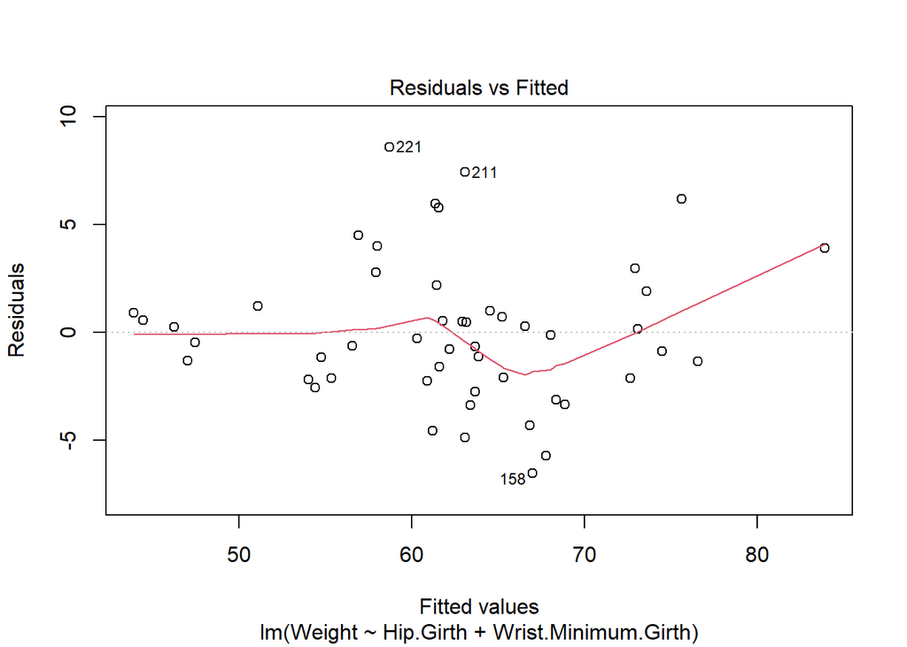

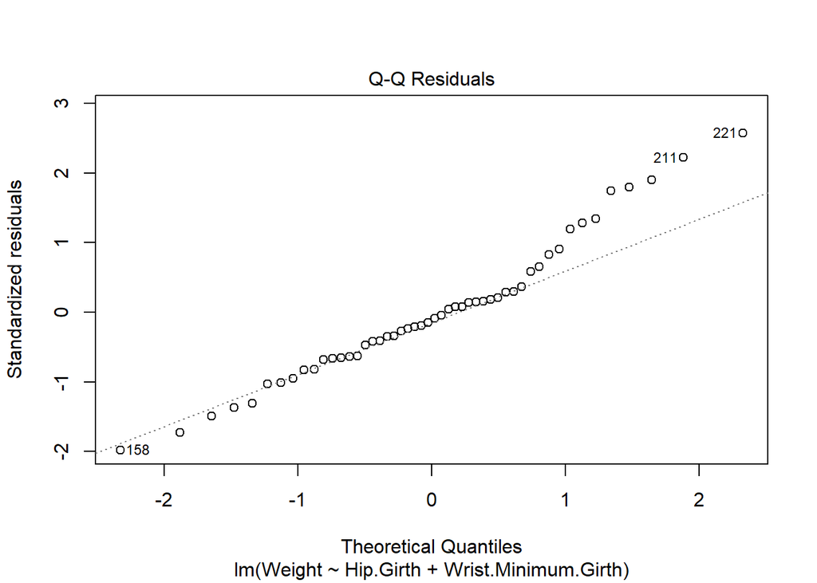

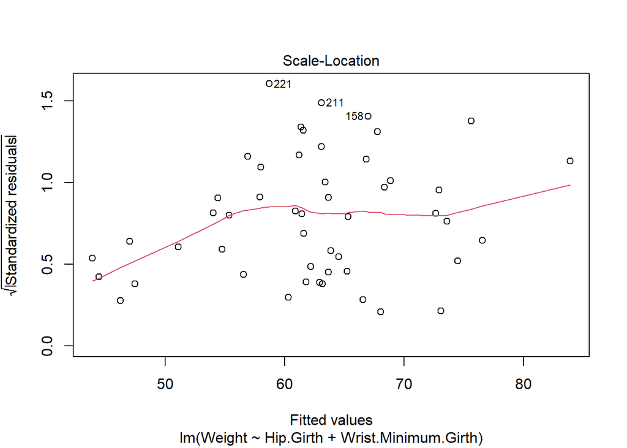

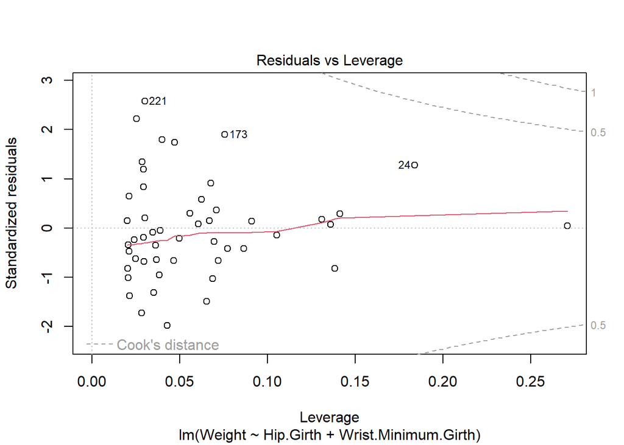

```r
modMejorado <- update(modMejorado, . ~ . + Wrist.Minimum.Girth)
plot(modMejorado)
```

```r
shapiro.test(modMejorado$residuals)
```

```
##
##  Shapiro-Wilk normality test
##
## data:  modMejorado$residuals
## W = 0.96752, p-value = 0.1831
```

```r
add1(modMejorado, scope = completo)
```

```
## Single term additions
##
## Model:
## Weight ~ Hip.Girth + Wrist.Minimum.Girth
##                         Df Sum of Sq    RSS    AIC
## <none>                               538.27 124.82
## Calf.Maximum.Girth       1    83.470 454.80 118.39
## Age                      1     3.713 534.56 126.47
## Chest.diameter           1    19.398 518.87 124.98
## Elbows.diameter          1    74.529 463.74 119.36
## Shoulder.Girth           1    53.668 484.60 121.56
## Chest.Girth              1   134.789 403.48 112.41
## Bitrochanteric.diameter  1     0.029 538.24 126.81
```

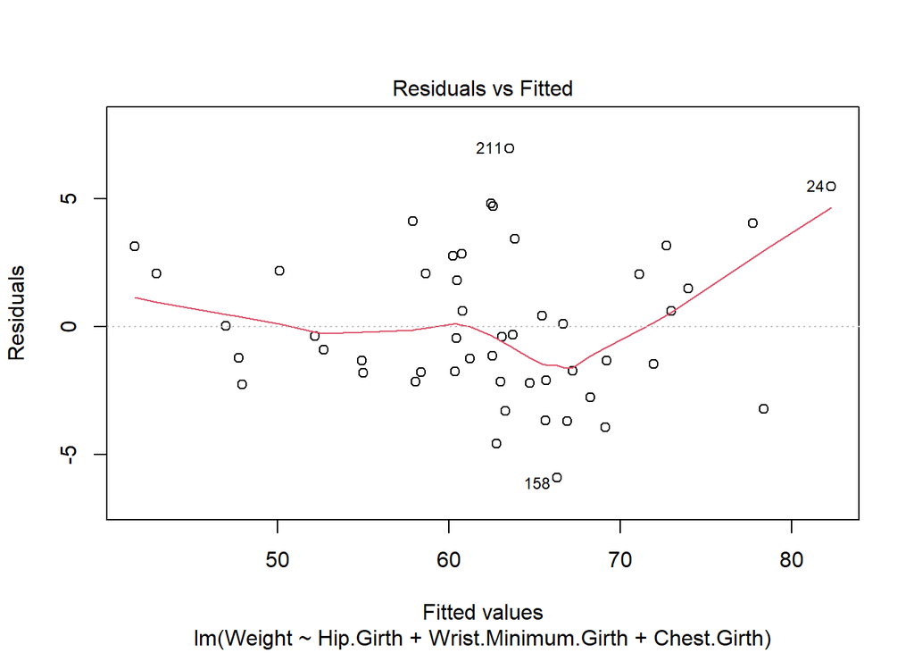

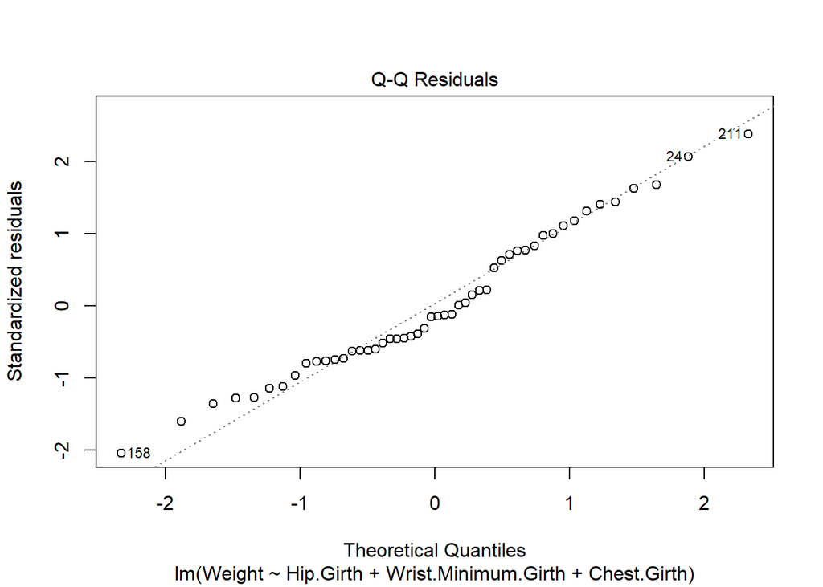

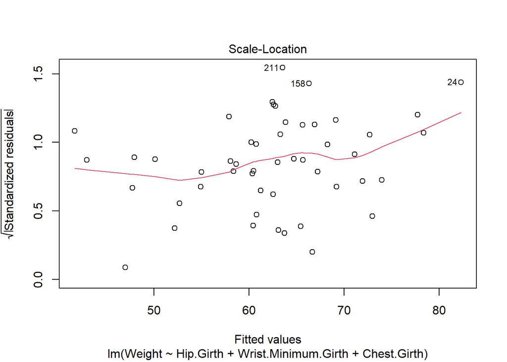

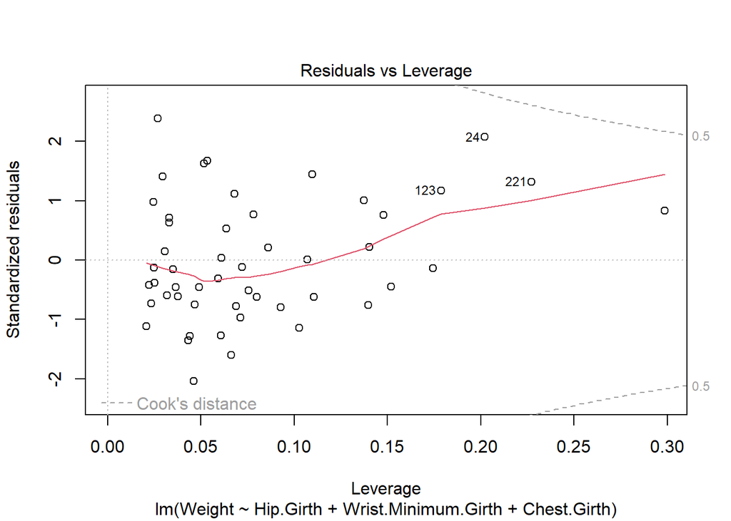

```r
modMejorado <- update(modMejorado, . ~ . + Chest.Girth)
plot(modMejorado)
```

```r
shapiro.test(modMejorado$residuals)
```

```
##
##  Shapiro-Wilk normality test
##
## data:  modMejorado$residuals
## W = 0.97503, p-value = 0.3658
```

```r
# Crear conjuntos de entrenamiento y prueba .
set.seed(1624)
n <- nrow(muestraP)
n_entrenamiento <- floor(0.7*n)
muestra <- sample.int(n = n, size = n_entrenamiento, replace = FALSE)
entrenamiento <- datos [muestra, ]
prueba <- datos [-muestra, ]

modelo <- lm(Weight ~ Hip.Girth + Wrist.Minimum.Girth + Chest.Girth, data = entrenamiento)
summary(modelo)
```

```
##
## Call:
## lm(formula = Weight ~ Hip.Girth + Wrist.Minimum.Girth + Chest.Girth,
##     data = entrenamiento)
##
## Residuals:
##     Min      1Q  Median      3Q     Max
## -5.3396 -1.6419 -0.4651  1.5179  7.7804
##
## Coefficients:
##                      Estimate Std. Error t value Pr(>|t|)
## (Intercept)         -102.4910    11.9342  -8.588 1.06e-09 ***
## Hip.Girth              1.3086     0.1395   9.381 1.44e-10 ***
## Wrist.Minimum.Girth    2.1983     0.7804   2.817  0.00836 **
## Chest.Girth            0.1430     0.1136   1.259  0.21743
## ---
## Signif. codes:  0 '***' 0.001 '**' 0.01 '*' 0.05 '.' 0.1 ' ' 1
##
## Residual standard error: 3.18 on 31 degrees of freedom
## Multiple R-squared:  0.8874, Adjusted R-squared:  0.8765
## F-statistic: 81.41 on 3 and 31 DF,  p-value: 8.603e-15
```

```r
mse_entrenamiento <- mean(modelo$residuals**2)
cat ("MSE para el conjunto de entrenamiento :", mse_entrenamiento, "\n")
```

```
## MSE para el conjunto de entrenamiento : 8.953906
```

```r
predicciones <- predict(modelo, prueba)

error <- prueba[["Weight"]] - predicciones
mse_prueba <- mean(error**2)
cat(" MSE para el conjunto de prueba :", mse_prueba)
```

```
##  MSE para el conjunto de prueba : 49.12029
```

```r
# Crear conjuntos de entrenamiento y prueba .
set.seed(1624)
n <- nrow(datos)
n_entrenamiento <- floor(0.7*n)
muestra <- sample.int ( n = n , size = n_entrenamiento , replace = FALSE )
entrenamiento <- datos [muestra,]
prueba <- datos [-muestra,]

# Ajustar modelo usando validaci ón cruzada de 5 pliegues .
modelo <- train (Weight ~ Hip.Girth + Wrist.Minimum.Girth + Chest.Girth, data = entrenamiento , method = "lm",
trControl = trainControl ( method = "cv", number = 5) )

summary(modelo)
```

```
##
## Call:
## lm(formula = .outcome ~ ., data = dat)
##
## Residuals:
##      Min       1Q   Median       3Q      Max
## -12.9738  -2.4814  -0.1427   2.4341  12.3380
##
## Coefficients:
##                       Estimate Std. Error t value Pr(>|t|)
## (Intercept)         -100.54071    3.45030 -29.140  < 2e-16 ***
## Hip.Girth              0.75889    0.03871  19.606  < 2e-16 ***
## Wrist.Minimum.Girth    2.25935    0.27474   8.224 3.91e-15 ***
## Chest.Girth            0.64172    0.04064  15.789  < 2e-16 ***
## ---
## Signif. codes:  0 '***' 0.001 '**' 0.01 '*' 0.05 '.' 0.1 ' ' 1
##
## Residual standard error: 3.962 on 350 degrees of freedom
## Multiple R-squared:  0.9125, Adjusted R-squared:  0.9118
## F-statistic:  1217 on 3 and 350 DF,  p-value: < 2.2e-16
```

```r
# Hacer predicciones para el conjunto de entrenamiento .
predicciones_entrenamiento <- predict(modelo,entrenamiento)

# Calcular error cuadrado promedio para el conjunto de prueba .
error_entrenamiento <- entrenamiento[["Weight"]] - predicciones_entrenamiento
mse_entrenamiento <- mean(error_entrenamiento**2)
cat ("MSE para el conjunto de entrenamiento :", mse_entrenamiento, "\n")
```

```
## MSE para el conjunto de entrenamiento : 15.52057
```

```r
# Hacer predicciones para el conjunto de prueba .
predicciones_prueba <- predict(modelo, prueba)

# Calcular error cuadrado promedio para el conjunto de prueba .
error_prueba <-prueba [["Weight"]] - predicciones_prueba
mse_prueba <- mean (error_prueba**2)
cat("MSE para el conjunto de prueba :", mse_prueba )
```

```
## MSE para el conjunto de prueba : 13.74959
```